# Analysis of Mixpace Marketing Group’s Customer Visit Data

Zhikang Xu

5/25/2018

# Introduction

## Purpose

Some of the relationships and plots we are going to investigate include:

- EDA plots of Mixpace’s Customer Visit Data from Marketing Group, such as the distribution of visitors’ size
- Relationships between Lease Success Ratio and other related feture, such as Visit Status

## Data and Methods

### Database Codebook

The expected datasets for the above analysis are described as below.

1. X1: Source Type: Company resource; other
2. X2: Source Detail : Detailed source type
3. X3: Industry: Specific Industry Category based on Company name and comments
4. X4: Type: Work, Commerce or Shop
5. X5: People: Size of People
6. X6: Recommendation_Space_1: The first Space we recommend for customers
7. X7: Recommendation_Space_2: The Second Space we recommend for customers
8. X8: Time of first visit: Date of first Visit
9. Y1: Lease_or_Not: Whether the customer signed the lease

# Analysis

## Load Package

The following packages are employed:

- plyr
- ggplot2
- fitdistrplus
- GGally
- lubridate
- mediation

## Load Data

The following datasets are included:

- marketing_report_s.csv
- Supersector_Table.csv
- Industry_Code_Table.csv

## Process Data

The Combined and Cleaned dataset is data_marketing_valid.

```
## 'data.frame':    185 obs. of  16 variables:
##  $ Industry_Code         : int  2000 2000 2000 2000 2000 2000 2000 2000 2000 2000 ...
##  $ Supersector           : int  2700 2700 2700 2700 2700 2700 2700 2700 2700 2700 ...
##  $ Reporter              : chr  "Yixiang_Liang" "Yixiang_Liang" "Chengyang_Ye" "Jinhui_Miu" ...
##  $ Source_Type           : chr  "Company" "Company" "Company" "Other" ...
##  $ Source_Detail         : chr  "Official_Number" "Website" "Other" "Third-Party" ...
##  $ Industry              : chr  "Transportation" "Training" "Consulting" "Transportation" ...
##  $ Type                  : chr  "Work" "Work" "Work" "Work" ...
##  $ People                : int  3 12 3 3 12 12 1 60 3 12 ...
##  $ Recommendation_Space_1: chr  "Phoenix" "Carlowitz" "Carlowitz" "Wonderwall" ...
##  $ Recommendation_Space_2: chr  "" "" "" "" ...
##  $ Visit_Status          : chr  "Yes" "Yes" "No" "Yes" ...
##  $ Lease_Status          : chr  "No" "No" "No" "No" ...
##  $ First_Contact_Date    : Factor w/ 66 levels "","1/3/2018",..: 52 65 14 24 4 25 59 23 19 10 ...
##  $ Lost_or_Not           : Factor w/ 3 levels "","No","Yes": 2 3 1 1 1 1 1 1 1 3 ...
##  $ Supersector_Name      : Factor w/ 19 levels "Automobiles & Parts",..: 9 9 9 9 9 9 9 9 9 9 ...
##  $ Industry_Name         : Factor w/ 11 levels "Basic Materials",..: 6 6 6 6 6 6 6 6 6 6 ...
```

## EDA Plots

The expected plots are as following: - Distribution of the number of valid visitors(Y) VS reporter(X)

### Distribution of the number of valid visitors(Y) VS reporter(X)

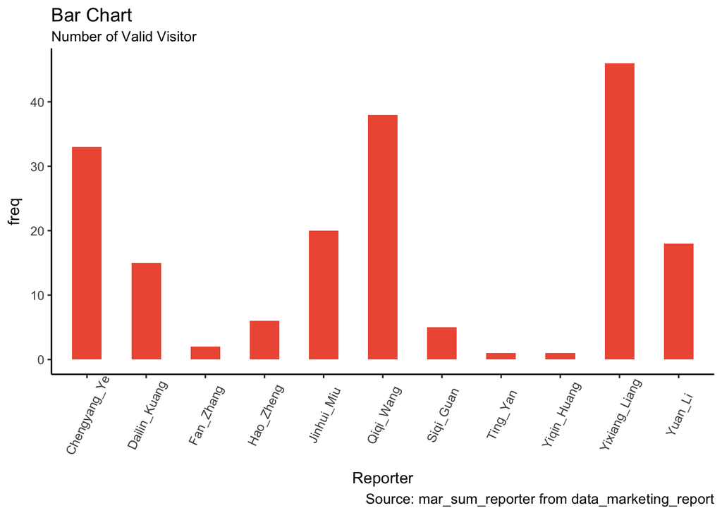

### Plots of the number of monthly valid visitors(Y) VS time(X), Categorized by Source Detail

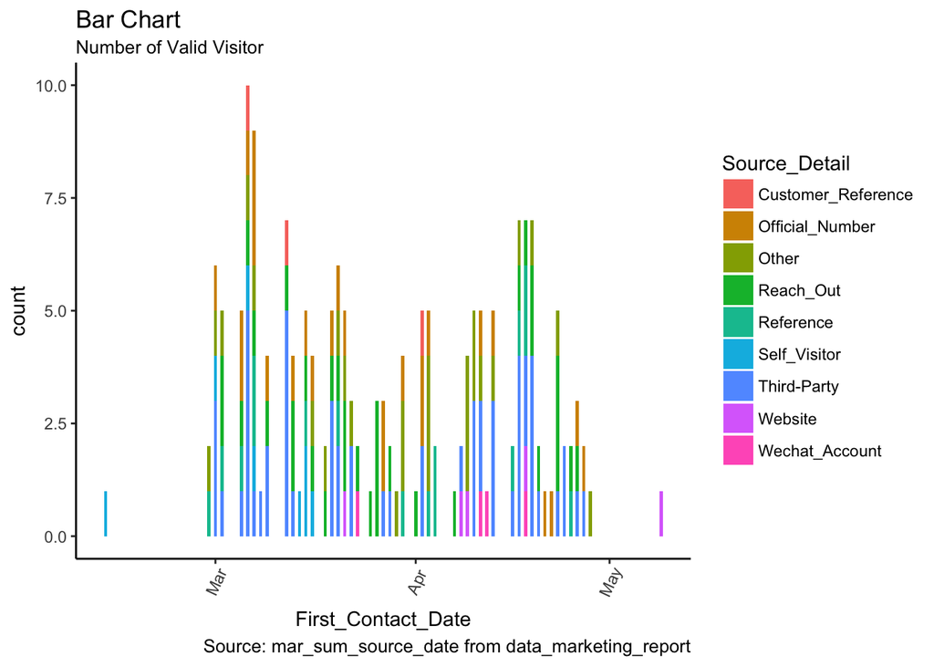

### Distribution of the total number of valid visitors(Y) VS Source(X), Categorized by Source Detail

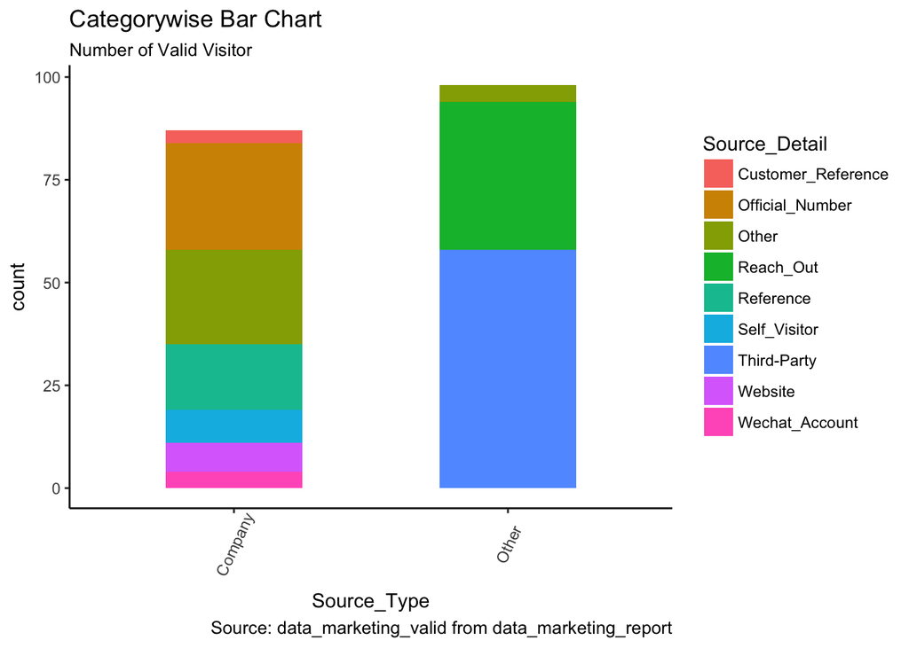

### Distribution of the number of valid visitors(Y) VS Specific Industry(X)

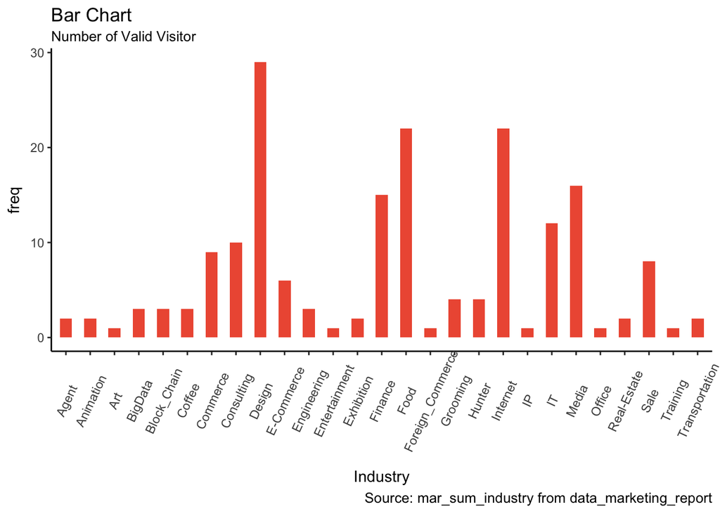

### Distribution of the number of valid visitors(Y) VS Industry (Supersector(X))

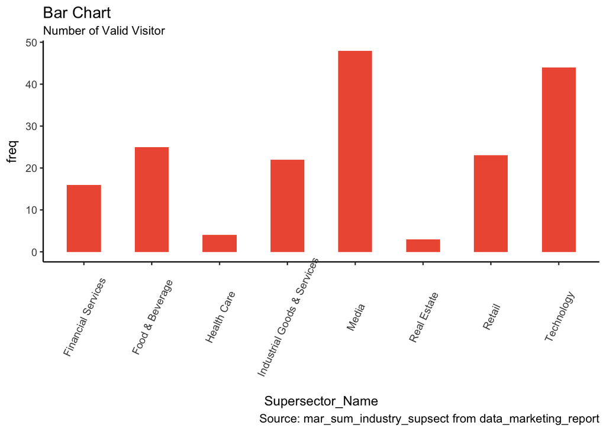

### Distribution of the number of valid visitors(Y) VS Industry (Second Industry Sector(X))

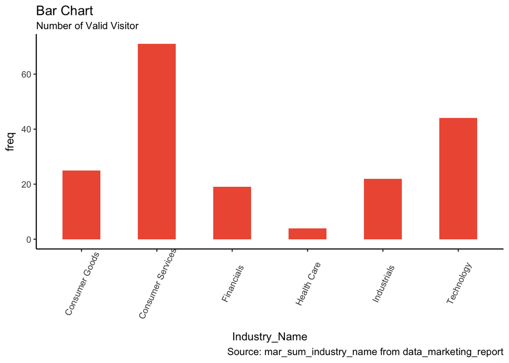

### Distribution of the number of valid visitors(Y) VS Type(X)

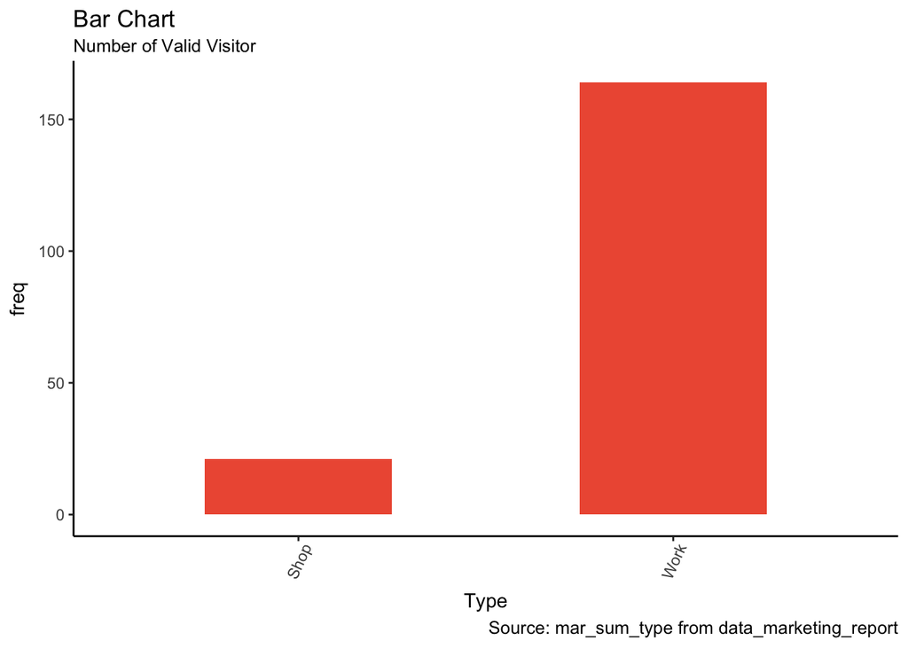

### Distribution of the number of People (Normal and Log)

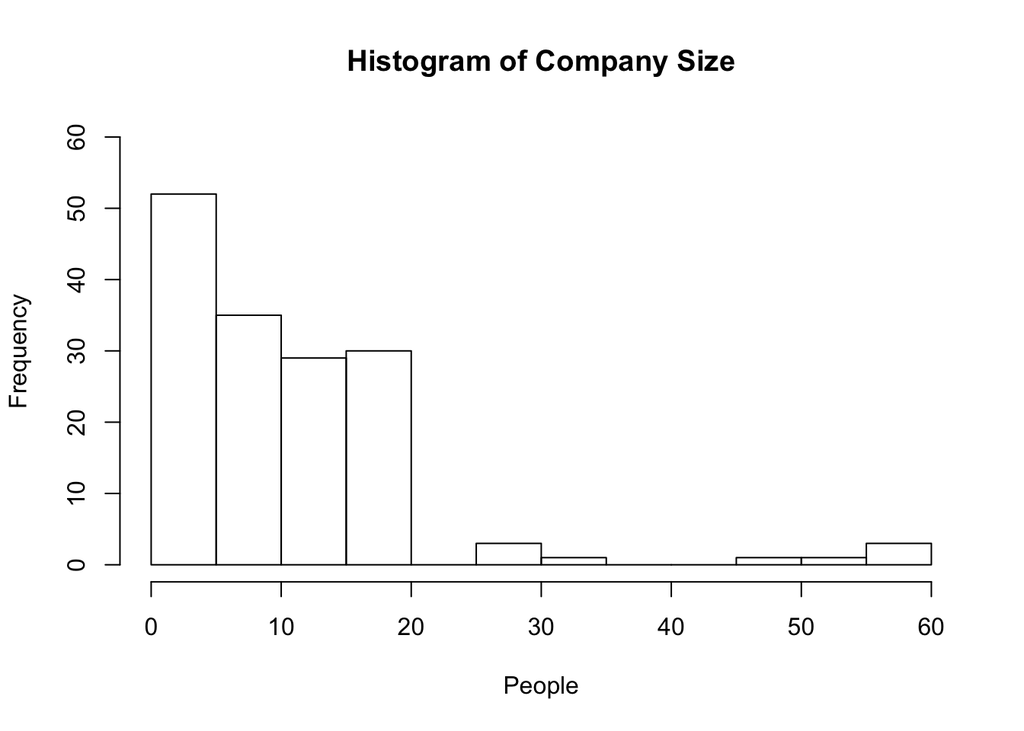

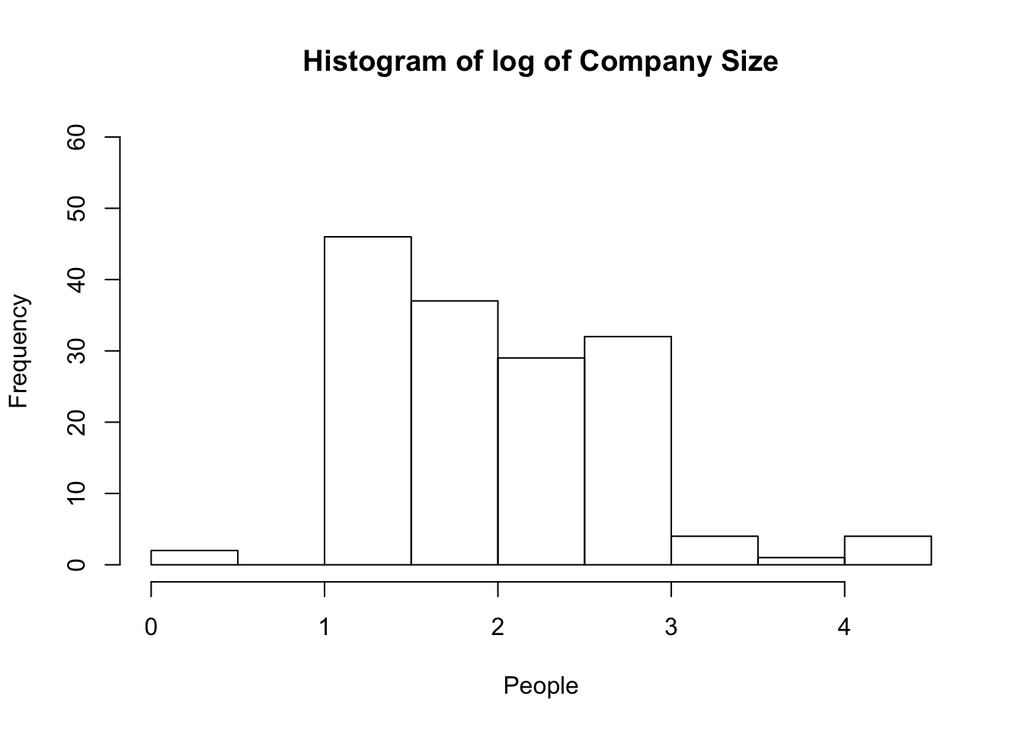

### Successful Ratio of lease(Y) VS People(x)

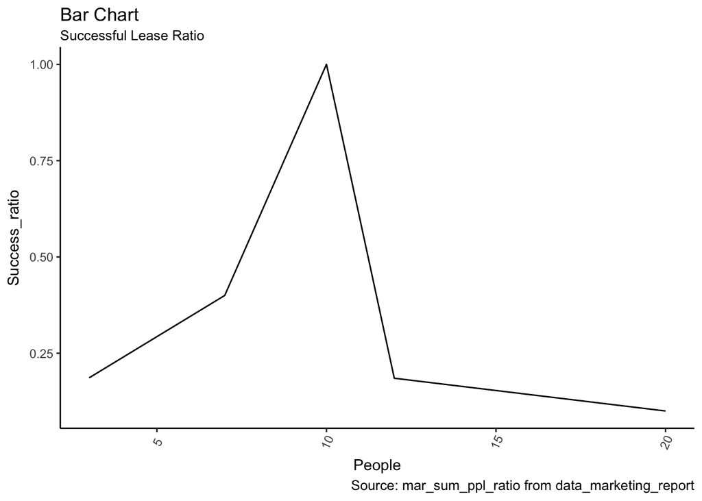

### Successful Ratio of lease(Y) VS Industry(x)

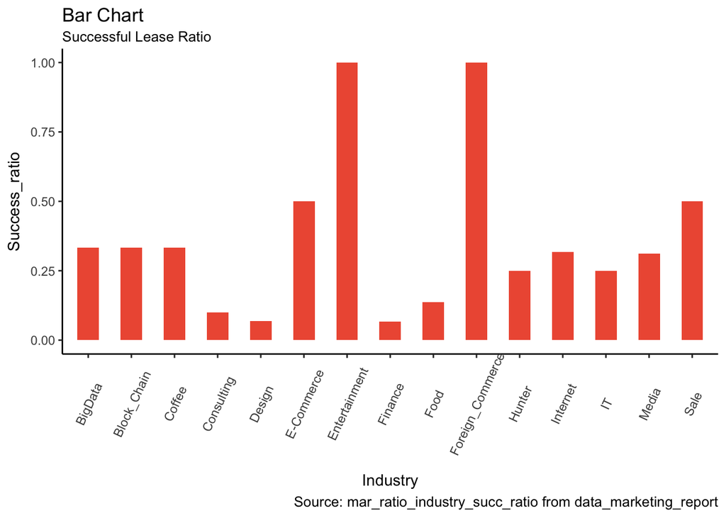

## Modeling

### Producing Combined DB

The prepared Database for modeling are DB_Mod, DB_Mod_Work and DB_Mod_Shop. The reason for doing so is that data with shop attribute should be considered seperately, which does not have valid data for people but also an feature of area.

```
## [1] "DB_Mod"
```

```
## 'data.frame':    185 obs. of  16 variables:
##  $ Industry_Code         : int  2000 2000 2000 2000 2000 2000 2000 2000 2000 2000 ...
##  $ Supersector           : int  2700 2700 2700 2700 2700 2700 2700 2700 2700 2700 ...
##  $ Source_Type           : chr  "Company" "Company" "Company" "Other" ...
##  $ Source_Detail         : chr  "Official_Number" "Website" "Other" "Third-Party" ...
##  $ Industry              : chr  "Transportation" "Training" "Consulting" "Transportation" ...
##  $ Type                  : chr  "Work" "Work" "Work" "Work" ...
##  $ People                : int  3 12 3 3 12 12 1 60 3 12 ...
##  $ Recommendation_Space_1: chr  "Phoenix" "Carlowitz" "Carlowitz" "Wonderwall" ...
##  $ Recommendation_Space_2: chr  "" "" "" "" ...
##  $ Visit_Status          : chr  "Yes" "Yes" "No" "Yes" ...
##  $ Lease_Status          : chr  "No" "No" "No" "No" ...
##  $ First_Contact_Date    : Date, format: "2018-04-03" "2018-04-09" ...
##  $ Lost_or_Not           : Factor w/ 3 levels "","No","Yes": 2 3 1 1 1 1 1 1 1 3 ...
##  $ Supersector_Name      : Factor w/ 19 levels "Automobiles & Parts",..: 9 9 9 9 9 9 9 9 9 9 ...
##  $ Industry_Name         : Factor w/ 11 levels "Basic Materials",..: 6 6 6 6 6 6 6 6 6 6 ...
##  $ year                  : num  2018 2018 2018 2018 2018 ...
```

```
## [1] "DB_Mod_Work"
```

```
## 'data.frame':    164 obs. of  12 variables:
##  $ Source_Type           : Factor w/ 2 levels "Company","Other": 1 1 1 2 2 2 1 2 1 1 ...
##  $ Source_Detail         : Factor w/ 9 levels "Customer_Reference",..: 2 8 3 7 7 7 3 3 8 3 ...
##  $ Industry              : Factor w/ 27 levels "Agent","Animation",..: 27 26 8 27 8 13 1 8 13 8 ...
##  $ People                : int  3 12 3 3 12 12 1 60 3 12 ...
##  $ Recommendation_Space_1: Factor w/ 11 levels "","Amyitis","breathing",..: 9 5 5 11 2 2 6 11 2 5 ...
##  $ Recommendation_Space_2: Factor w/ 8 levels "","Amyitis","Carlowitz",..: 1 1 1 1 1 1 1 1 1 1 ...
##  $ Visit_Status          : Factor w/ 2 levels "0","1": 2 2 1 2 2 2 2 1 2 1 ...
##  $ Lease_Status          : Factor w/ 2 levels "0","1": 1 1 1 1 2 1 1 1 1 1 ...
##  $ First_Contact_Date    : Date, format: "2018-04-03" "2018-04-09" ...
##  $ Lost_or_Not           : Factor w/ 3 levels "","No","Yes": 2 3 1 1 1 1 1 1 1 3 ...
##  $ Supersector_Name      : Factor w/ 19 levels "Automobiles & Parts",..: 9 9 9 9 9 9 9 9 9 9 ...
##  $ Industry_Name         : Factor w/ 11 levels "Basic Materials",..: 6 6 6 6 6 6 6 6 6 6 ...
```

```
## [1] "DB_Mod_Shop"
```

```
## 'data.frame':    21 obs. of  11 variables:
##  $ Source_Type           : Factor w/ 2 levels "Company","Other": 2 2 2 2 1 1 1 2 1 2 ...
##  $ Source_Detail         : Factor w/ 9 levels "Customer_Reference",..: 4 4 7 4 2 5 5 7 2 7 ...
##  $ Industry              : Factor w/ 27 levels "Agent","Animation",..: 15 15 15 15 15 15 15 15 15 15 ...
##  $ Recommendation_Space_1: Factor w/ 11 levels "","Amyitis","breathing",..: 7 7 7 7 3 7 7 7 3 7 ...
##  $ Recommendation_Space_2: Factor w/ 8 levels "","Amyitis","Carlowitz",..: 1 1 1 1 1 1 1 1 1 1 ...
##  $ Visit_Status          : Factor w/ 2 levels "0","1": 2 2 2 2 1 2 2 2 2 2 ...
##  $ Lease_Status          : Factor w/ 2 levels "0","1": 1 1 1 1 1 1 1 2 2 1 ...
##  $ First_Contact_Date    : Date, format: "2018-04-07" "2018-03-13" ...
##  $ Lost_or_Not           : Factor w/ 3 levels "","No","Yes": 1 2 1 1 1 2 1 1 1 1 ...
##  $ Supersector_Name      : Factor w/ 19 levels "Automobiles & Parts",..: 7 7 7 7 7 7 7 7 7 7 ...
##  $ Industry_Name         : Factor w/ 11 levels "Basic Materials",..: 2 2 2 2 2 2 2 2 2 2 ...
```

### Relationships Analysis

#### Type and Lease_Status

The relationships between Lease_Status and Type are as follow. It turns out that Type is not significant for lease_status.

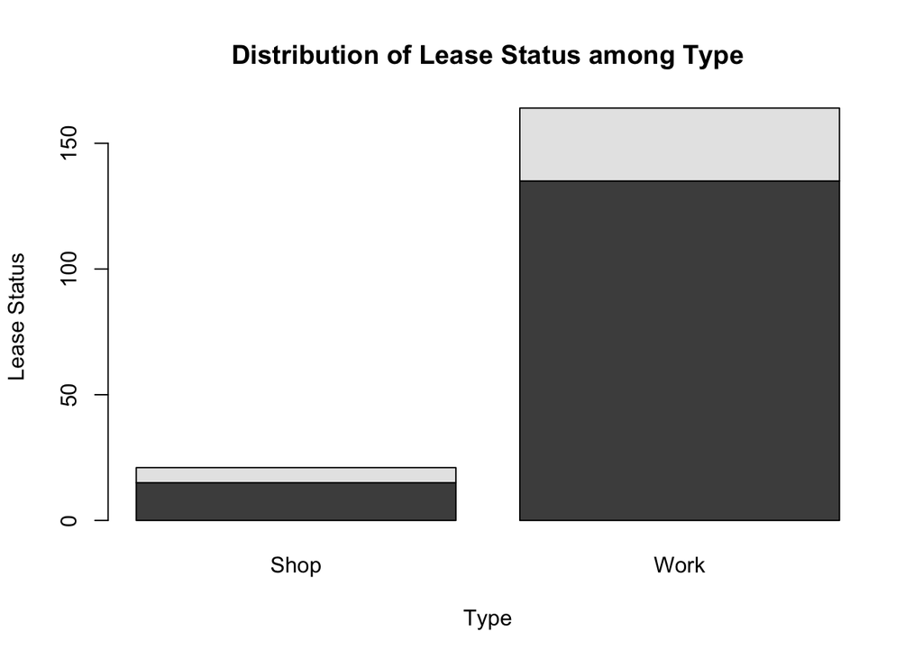

```
##
## Call:
## glm(formula = Lease_Status ~ Type, family = binomial, data = DB_Mod)
##
## Deviance Residuals:
##     Min       1Q   Median       3Q      Max
## -0.8203  -0.6239  -0.6239  -0.6239   1.8615
##
## Coefficients:
##             Estimate Std. Error z value Pr(>|z|)
## (Intercept)  -0.9163     0.4830  -1.897   0.0578 .
## TypeWork     -0.6217     0.5246  -1.185   0.2360
## ---
## Signif. codes:  0 '***' 0.001 '**' 0.01 '*' 0.05 '.' 0.1 ' ' 1
##
## (Dispersion parameter for binomial family taken to be 1)
##
##     Null deviance: 179.47  on 184  degrees of freedom
## Residual deviance: 178.16  on 183  degrees of freedom
## AIC: 182.16
##
## Number of Fisher Scoring iterations: 4
```

#### Industry_Code and Lease_Status

The relationships between Lease_Status and Industry_Code are as follow. It turns out that Industry_Code is not significant for lease_status.

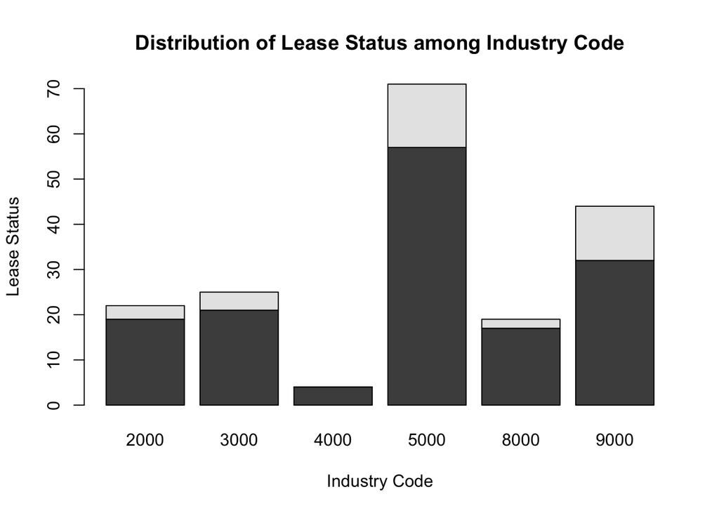

```
##
## Call:
## glm(formula = Lease_Status ~ Industry_Code, family = binomial,
##     data = DB_Mod)
##
## Deviance Residuals:
##     Min       1Q   Median       3Q      Max
## -0.7981  -0.6628  -0.5905  -0.4717   2.1219
##
## Coefficients:
##                    Estimate Std. Error z value Pr(>|z|)
## (Intercept)         -1.8458     0.6213  -2.971  0.00297 **
## Industry_Code3000    0.1876     0.8268   0.227  0.82050
## Industry_Code4000  -14.7202  1199.7725  -0.012  0.99021
## Industry_Code5000    0.4418     0.6892   0.641  0.52144
## Industry_Code8000   -0.2942     0.9720  -0.303  0.76211
## Industry_Code9000    0.8650     0.7075   1.223  0.22147
## ---
## Signif. codes:  0 '***' 0.001 '**' 0.01 '*' 0.05 '.' 0.1 ' ' 1
##
## (Dispersion parameter for binomial family taken to be 1)
##
##     Null deviance: 179.47  on 184  degrees of freedom
## Residual deviance: 174.36  on 179  degrees of freedom
## AIC: 186.36
##
## Number of Fisher Scoring iterations: 15
```

#### Source_Type and Lease_Status

The relationships between Lease_Status and Source_Type are as follow. It turns out that Source_Type is significant for lease_status.

[figure not shown]

```
##
## Call:
## glm(formula = Lease_Status ~ Source_Type, family = binomial,
##     data = DB_Mod)
##
## Deviance Residuals:
##     Min       1Q   Median       3Q      Max
## -0.7495  -0.7495  -0.5200  -0.5200   2.0337
##
## Coefficients:
##                  Estimate Std. Error z value Pr(>|z|)
## (Intercept)       -1.9328     0.3226  -5.992 2.08e-09 ***
## Source_TypeOther   0.8068     0.3991   2.022   0.0432 *
## ---
## Signif. codes:  0 '***' 0.001 '**' 0.01 '*' 0.05 '.' 0.1 ' ' 1
##
## (Dispersion parameter for binomial family taken to be 1)
##
##     Null deviance: 179.47  on 184  degrees of freedom
## Residual deviance: 175.15  on 183  degrees of freedom
## AIC: 179.15
##
## Number of Fisher Scoring iterations: 4
```

#### People and Lease_Status

The relationships between Lease_Status and log(People) are as follow. It turns out that log(People) is not significant for lease_status.

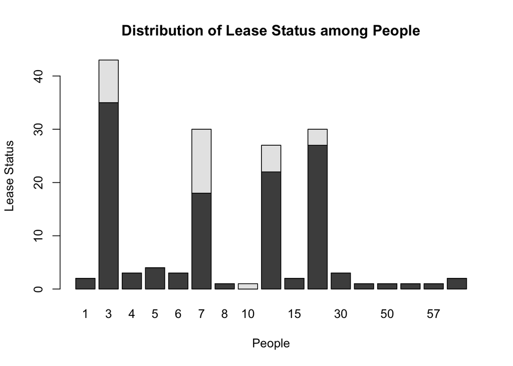

```
##
## Call:
## glm(formula = Lease_Status ~ log(People), family = binomial,
##     data = DB_Mod)
##
## Deviance Residuals:
##     Min       1Q   Median       3Q      Max
## -0.8175  -0.6948  -0.6080  -0.5707   1.9469
##
## Coefficients:
##             Estimate Std. Error z value Pr(>|z|)
## (Intercept)  -0.9243     0.5320  -1.737   0.0823 .
## log(People)  -0.2697     0.2500  -1.079   0.2806
## ---
## Signif. codes:  0 '***' 0.001 '**' 0.01 '*' 0.05 '.' 0.1 ' ' 1
##
## (Dispersion parameter for binomial family taken to be 1)
##
##     Null deviance: 149.42  on 154  degrees of freedom
## Residual deviance: 148.23  on 153  degrees of freedom
##   (30 observations deleted due to missingness)
## AIC: 152.23
##
## Number of Fisher Scoring iterations: 4
```

#### Recommendation_Number and Lease_Status

The relationships between Lease_Status and Rec_NO are as follow. It turns out that Rec_NO is not significant for lease_status.

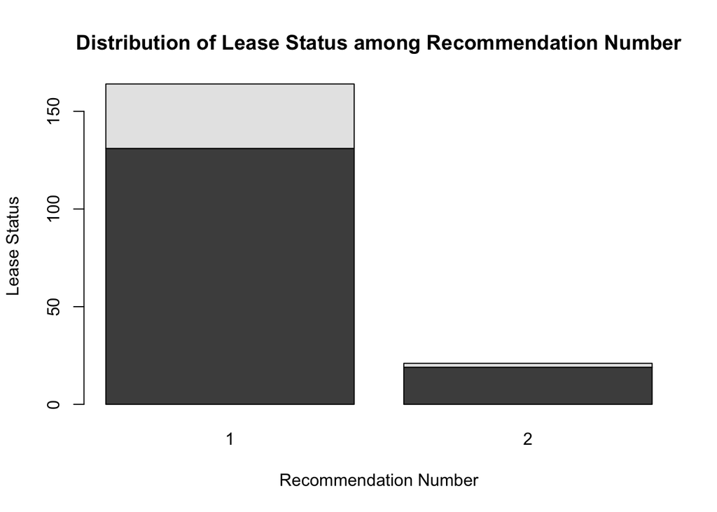

```
##
## Call:
## glm(formula = Lease_Status ~ as.factor(Rec_NO), family = binomial,
##     data = DB_Mod)
##
## Deviance Residuals:
##     Min       1Q   Median       3Q      Max
## -0.6703  -0.6703  -0.6703  -0.4474   2.1686
##
## Coefficients:
##                    Estimate Std. Error z value Pr(>|z|)
## (Intercept)         -1.3787     0.1948  -7.078 1.46e-12 ***
## as.factor(Rec_NO)2  -0.8726     0.7684  -1.136    0.256
## ---
## Signif. codes:  0 '***' 0.001 '**' 0.01 '*' 0.05 '.' 0.1 ' ' 1
##
## (Dispersion parameter for binomial family taken to be 1)
##
##     Null deviance: 179.47  on 184  degrees of freedom
## Residual deviance: 177.89  on 183  degrees of freedom
## AIC: 181.89
##
## Number of Fisher Scoring iterations: 4
```

#### Recommendation_Space_1 and Lease_Status

The relationships between Lease_Status and Recommendation_Space_1 are as follow. It turns out that Recommendation_Space_1 is not significant for lease_status.

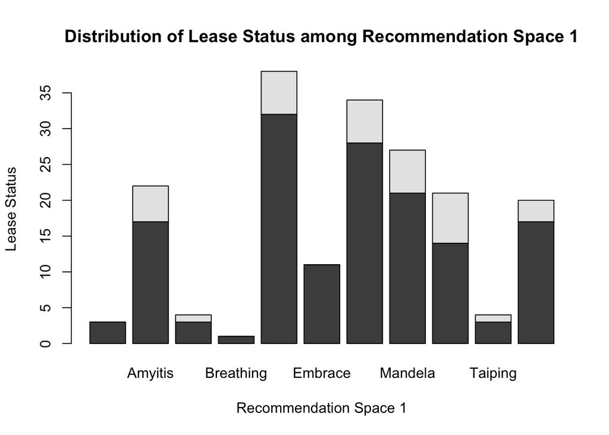

```
##
## Call:
## glm(formula = Lease_Status ~ Recommendation_Space_1, family = binomial,
##     data = DB_Mod)
##
## Deviance Residuals:
##      Min        1Q    Median        3Q       Max
## -0.90052  -0.70896  -0.58626  -0.00022   1.94788
##
## Coefficients:
##                                    Estimate Std. Error z value Pr(>|z|)
## (Intercept)                      -1.757e+01  2.284e+03  -0.008    0.994
## Recommendation_Space_1Amyitis     1.634e+01  2.284e+03   0.007    0.994
## Recommendation_Space_1breathing   1.647e+01  2.284e+03   0.007    0.994
## Recommendation_Space_1Breathing   6.228e-10  4.568e+03   0.000    1.000
## Recommendation_Space_1Carlowitz   1.589e+01  2.284e+03   0.007    0.994
## Recommendation_Space_1Embrace     7.065e-10  2.577e+03   0.000    1.000
## Recommendation_Space_1Here        1.603e+01  2.284e+03   0.007    0.994
## Recommendation_Space_1Mandela     1.631e+01  2.284e+03   0.007    0.994
## Recommendation_Space_1Phoenix     1.687e+01  2.284e+03   0.007    0.994
## Recommendation_Space_1Taiping     1.647e+01  2.284e+03   0.007    0.994
## Recommendation_Space_1Wonderwall  1.583e+01  2.284e+03   0.007    0.994
##
## (Dispersion parameter for binomial family taken to be 1)
##
##     Null deviance: 179.47  on 184  degrees of freedom
## Residual deviance: 169.66  on 174  degrees of freedom
## AIC: 191.66
##
## Number of Fisher Scoring iterations: 16
```

#### Visit_Status and Lease_Status

The relationships between Lease_Status and Visit_Status are as follow. It turns out that Visit_Status is significant for lease_status.

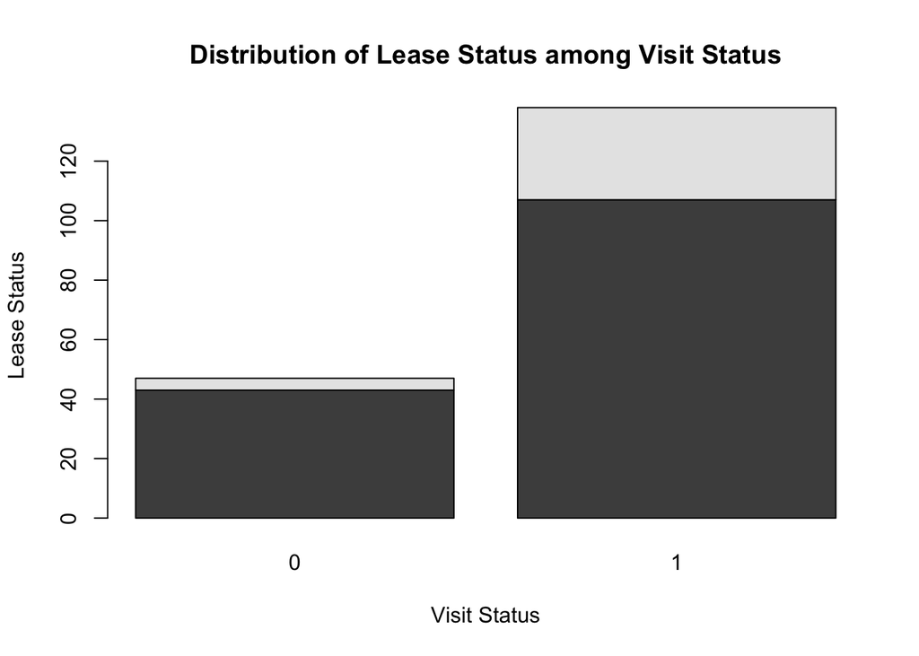

```
##
## Call:
## glm(formula = Lease_Status ~ Visit_Status, family = binomial,
##     data = DB_Mod)
##
## Deviance Residuals:
##     Min       1Q   Median       3Q      Max
## -0.7133  -0.7133  -0.7133  -0.4218   2.2198
##
## Coefficients:
##               Estimate Std. Error z value Pr(>|z|)
## (Intercept)    -2.3749     0.5227  -4.543 5.54e-06 ***
## Visit_Status1   1.1361     0.5611   2.025   0.0429 *
## ---
## Signif. codes:  0 '***' 0.001 '**' 0.01 '*' 0.05 '.' 0.1 ' ' 1
##
## (Dispersion parameter for binomial family taken to be 1)
##
##     Null deviance: 179.47  on 184  degrees of freedom
## Residual deviance: 174.39  on 183  degrees of freedom
## AIC: 178.39
##
## Number of Fisher Scoring iterations: 5
```

#### Source Detail and Lease_Status

The relationships between Lease_Status and Source_Detail (considering only “Reach_Out” and “Third-Party” due to data amount) are as follow. It turns out that Source_Detail is not significant for lease_status.

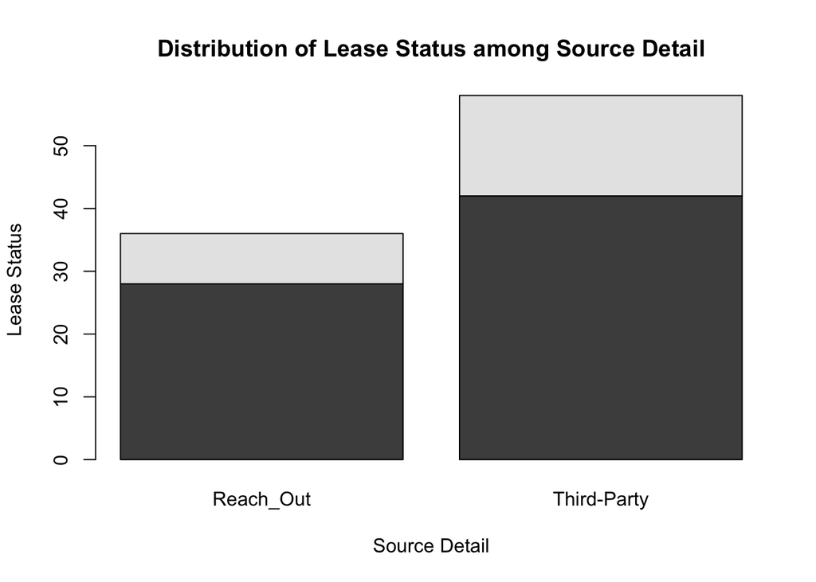

```
##
## Call:
## glm(formula = Lease_Status ~ Source_Detail, family = binomial,
##     data = t1)
##
## Deviance Residuals:
##     Min       1Q   Median       3Q      Max
## -0.8035  -0.8035  -0.7090   1.0264   1.7344
##
## Coefficients:
##                          Estimate Std. Error z value Pr(>|z|)
## (Intercept)               -1.2528     0.4009  -3.125  0.00178 **
## Source_DetailThird-Party   0.2877     0.4970   0.579  0.56271
## ---
## Signif. codes:  0 '***' 0.001 '**' 0.01 '*' 0.05 '.' 0.1 ' ' 1
##
## (Dispersion parameter for binomial family taken to be 1)
##
##     Null deviance: 106.80  on 93  degrees of freedom
## Residual deviance: 106.46  on 92  degrees of freedom
## AIC: 110.46
##
## Number of Fisher Scoring iterations: 4
```

### Mediation Analysis

#### Regresssion

Regress m ~ x (mediator ~ explanatory variable) and y ~ m + x (response variable ~ mediator + explanatory variable).

```
##
## Call:
## glm(formula = Visit_Status ~ Src_Type_Med, family = binomial,
##     data = DB_Mod)
##
## Deviance Residuals:
##     Min       1Q   Median       3Q      Max
## -2.0100  -1.3708   0.5335   0.9956   0.9956
##
## Coefficients:
##              Estimate Std. Error z value Pr(>|z|)
## (Intercept)    0.4439     0.2197   2.020 0.043344 *
## Src_Type_Med   1.4338     0.3701   3.874 0.000107 ***
## ---
## Signif. codes:  0 '***' 0.001 '**' 0.01 '*' 0.05 '.' 0.1 ' ' 1
##
## (Dispersion parameter for binomial family taken to be 1)
##
##     Null deviance: 209.70  on 184  degrees of freedom
## Residual deviance: 193.14  on 183  degrees of freedom
## AIC: 197.14
##
## Number of Fisher Scoring iterations: 4
```

```
##
## Call:
## glm(formula = Lease_Status ~ Visit_Status + Src_Type_Med, family = binomial,
##     data = DB_Mod)
##
## Deviance Residuals:
##     Min       1Q   Median       3Q      Max
## -0.7822  -0.7822  -0.5951  -0.3826   2.3025
##
## Coefficients:
##              Estimate Std. Error z value Pr(>|z|)
## (Intercept)   -3.5137     1.0696  -3.285  0.00102 **
## Visit_Status   0.9361     0.5777   1.620  0.10516
## Src_Type_Med   0.6138     0.4125   1.488  0.13678
## ---
## Signif. codes:  0 '***' 0.001 '**' 0.01 '*' 0.05 '.' 0.1 ' ' 1
##
## (Dispersion parameter for binomial family taken to be 1)
##
##     Null deviance: 179.47  on 184  degrees of freedom
## Residual deviance: 172.09  on 182  degrees of freedom
## AIC: 178.09
##
## Number of Fisher Scoring iterations: 5
```

#### Mediation Model

Run the Mediation model as follow.

```
##
## Causal Mediation Analysis
##
## Nonparametric Bootstrap Confidence Intervals with the Percentile Method
##
##                           Estimate 95% CI Lower 95% CI Upper p-value
## ACME (control)            8.11e-03    -5.35e-06         0.02   0.052 .
## ACME (treated)            1.38e-02    -9.04e-06         0.03   0.052 .
## ADE (control)             4.24e-02    -1.04e-02         0.15   0.146
## ADE (treated)             4.80e-02    -1.31e-02         0.16   0.146
## Total Effect              5.61e-02     7.45e-10         0.16   0.050 *
## Prop. Mediated (control)  1.44e-01    -1.50e-01         1.43   0.098 .
## Prop. Mediated (treated)  2.46e-01    -1.82e-01         1.33   0.098 .
## ACME (average)            1.10e-02    -7.59e-06         0.02   0.052 .
## ADE (average)             4.52e-02    -1.19e-02         0.16   0.146
## Prop. Mediated (average)  1.95e-01    -1.64e-01         1.38   0.098 .
## ---
## Signif. codes:  0 '***' 0.001 '**' 0.01 '*' 0.05 '.' 0.1 ' ' 1
##
## Sample Size Used: 185
##
##
## Simulations: 1000
```

# Conclusion

## Interpretation

According to the exploratory data analysis result, among all the variables considered, only “Source Type” and “Visit Status” have significant effect on the variable of interest “Lease Status”. Thus only these two variables would be used during modeling process. Logistic regression is further employed to explore the relationship between “Source Type” and “Visit Status”. Since these two variables are highly correlated, linear model should not be used here due to multicollinearity problem, which could lead to biased estimates.

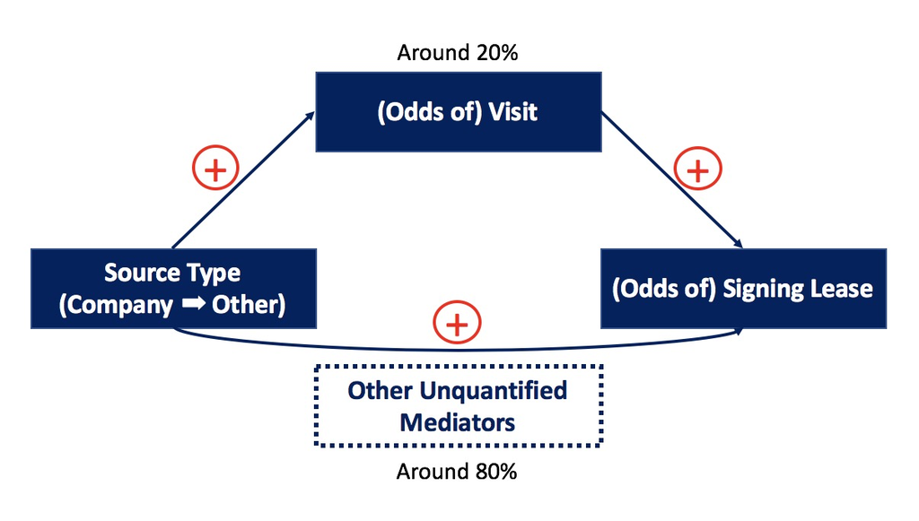

Mediation Model Explanation.